# Linear, Logistic regression and Survival Analysis of the Addicts and Bladder data sets

Sasha Ajay Malkani

2025-12-01

## 1. Install packages

```r
# install.packages("psych")
# install.packages("survival")
# install.packages("ROCR")
```

## 2. Load Libraries

```r
library(psych)
library(survival)
library(ROCR)
```

## 3. Load Data

```r
addicts = read.csv("addicts.csv")
head(addicts)
```

```
##   id clinic status survt prison dose
## 1  1      1      1   428      0   50
## 2  2      1      1   275      1   55
## 3  3      1      1   262      0   55
## 4  4      1      1   183      0   30
## 5  5      1      1   259      1   65
## 6  6      1      1   714      0   55
```

```r
# addicts[1:5,]
# addicts[1:5,1:6]
```

## 4. Summary of survival time data (univariate analysis)

```r
summary(addicts[c("clinic","status","survt","prison","dose")])
```

```
##      clinic          status           survt            prison
##  Min.   :1.000   Min.   :0.0000   Min.   :   2.0   Min.   :0.0000
##  1st Qu.:1.000   1st Qu.:0.0000   1st Qu.: 171.2   1st Qu.:0.0000
##  Median :1.000   Median :1.0000   Median : 367.5   Median :0.0000
##  Mean   :1.315   Mean   :0.6303   Mean   : 402.6   Mean   :0.4664
##  3rd Qu.:2.000   3rd Qu.:1.0000   3rd Qu.: 585.5   3rd Qu.:1.0000
##  Max.   :2.000   Max.   :1.0000   Max.   :1076.0   Max.   :1.0000
##       dose
##  Min.   : 20.0
##  1st Qu.: 50.0
##  Median : 60.0
##  Mean   : 60.4
##  3rd Qu.: 70.0
##  Max.   :110.0
```

```r
summary(addicts$survt)
```

```
##    Min. 1st Qu.  Median    Mean 3rd Qu.    Max.
##     2.0   171.2   367.5   402.6   585.5  1076.0
```

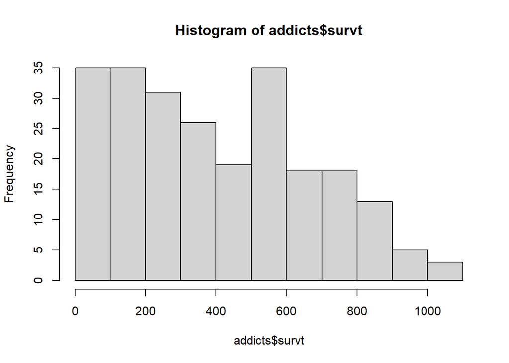

```r
hist(addicts$survt)
```

```r
summary(addicts$clinic)
```

```
##    Min. 1st Qu.  Median    Mean 3rd Qu.    Max.
##   1.000   1.000   1.000   1.315   2.000   2.000
```

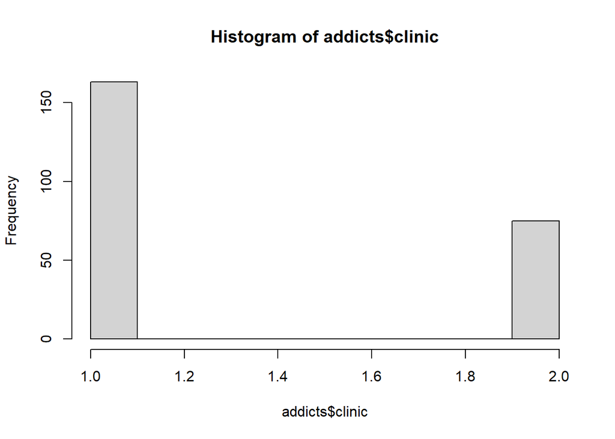

```r
hist(addicts$clinic)
```

```r
summary(addicts$prison)
```

```
##    Min. 1st Qu.  Median    Mean 3rd Qu.    Max.
##  0.0000  0.0000  0.0000  0.4664  1.0000  1.0000
```

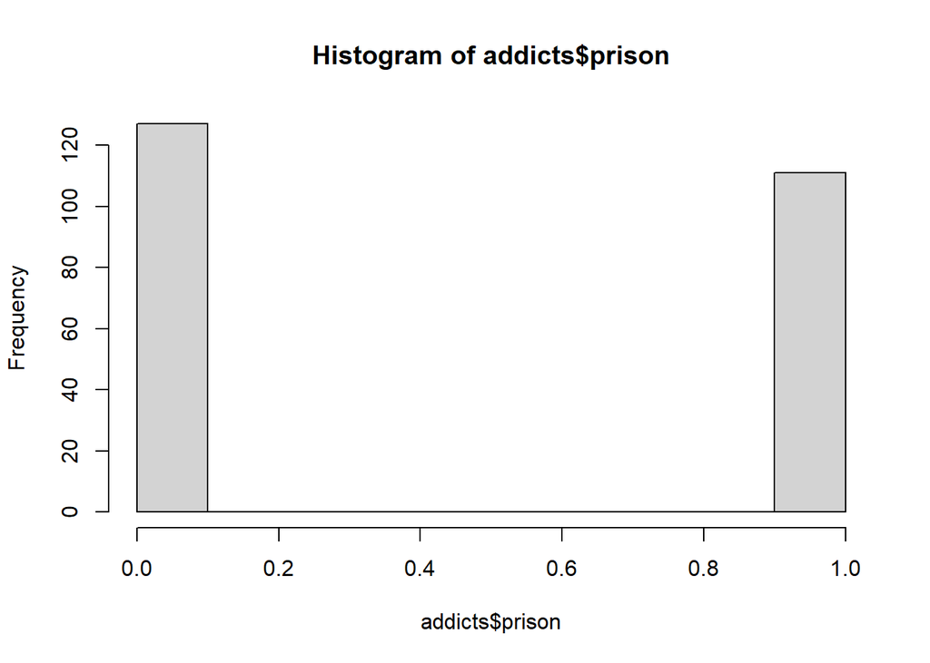

```r
hist(addicts$prison)
```

```r
table(addicts$clinic)
```

```
##
##   1   2
## 163  75
```

## 5. Enhanced Scatterplot matrix (bivarate analysis)

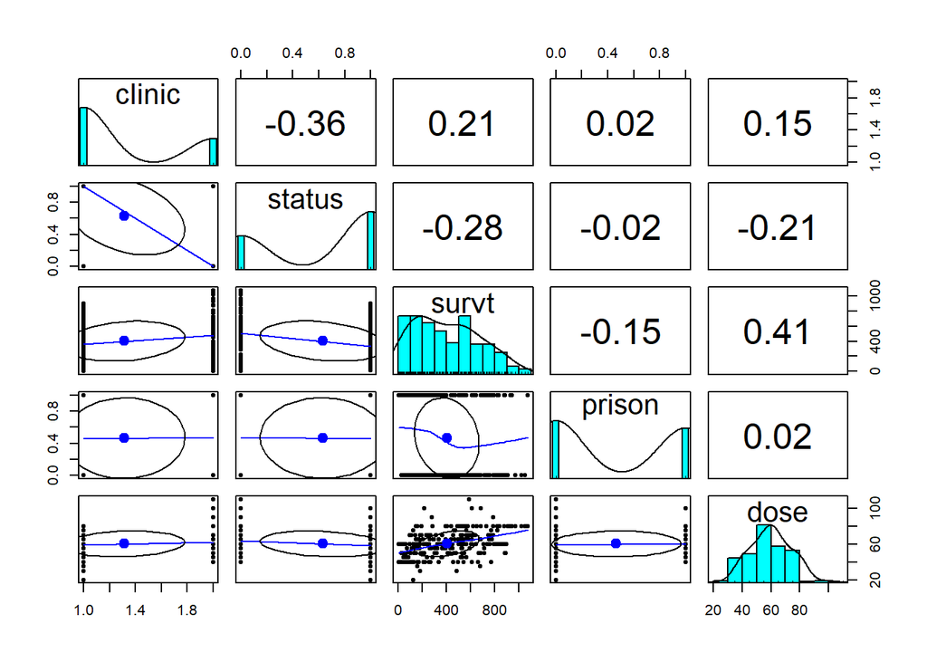

```r
pairs.panels(addicts[c("clinic","status","survt","prison","dose")])
```

## 6. Multiple linear regression model

### 6. A. Creating Multiple linear regression model

```r
linearregr_model <- lm(status ~ clinic + survt + prison + dose, data = addicts)

linearregr_model
```

```
##
## Call:
## lm(formula = status ~ clinic + survt + prison + dose, data = addicts)
##
## Coefficients:
## (Intercept)       clinic        survt       prison         dose
##   1.3779307   -0.3218080   -0.0003346   -0.0347147   -0.0028736
```

### 6. B. Multiple linear regression model - Detailed output

```r
summary(linearregr_model)
```

```
##
## Call:
## lm(formula = status ~ clinic + survt + prison + dose, data = addicts)
##
## Residuals:
##     Min      1Q  Median      3Q     Max
## -0.9084 -0.3373  0.1785  0.3151  0.7666
##
## Coefficients:
##               Estimate Std. Error t value Pr(>|t|)
## (Intercept)  1.3779307  0.1413189   9.751  < 2e-16 ***
## clinic      -0.3218080  0.0631294  -5.098 7.12e-07 ***
## survt       -0.0003346  0.0001207  -2.773  0.00601 **
## prison      -0.0347147  0.0582577  -0.596  0.55183
## dose        -0.0028736  0.0021883  -1.313  0.19041
## ---
## Signif. codes:  0 '***' 0.001 '**' 0.01 '*' 0.05 '.' 0.1 ' ' 1
##
## Residual standard error: 0.4413 on 233 degrees of freedom
## Multiple R-squared:  0.1819, Adjusted R-squared:  0.1679
## F-statistic: 12.95 on 4 and 233 DF,  p-value: 1.54e-09
```

## 7. Logistic regression model

### 7. A. Creating Logistic regression model

```r
logistic_model <- glm(formula=status ~ clinic + survt + prison + dose, data = addicts, family ="binomial")

logistic_model
```

```
##
## Call:  glm(formula = status ~ clinic + survt + prison + dose, family = "binomial",
##     data = addicts)
##
## Coefficients:
## (Intercept)       clinic        survt       prison         dose
##    4.151634    -1.451557    -0.001674    -0.191796    -0.014415
##
## Degrees of Freedom: 237 Total (i.e. Null);  233 Residual
## Null Deviance:       313.6
## Residual Deviance: 269   AIC: 279
```

### 7. B. Logistic regression model - Detailed output

```r
summary(logistic_model)
```

```
##
## Call:
## glm(formula = status ~ clinic + survt + prison + dose, family = "binomial",
##     data = addicts)
##
## Coefficients:
##               Estimate Std. Error z value Pr(>|z|)
## (Intercept)  4.1516345  0.7858315   5.283 1.27e-07 ***
## clinic      -1.4515571  0.3109073  -4.669 3.03e-06 ***
## survt       -0.0016738  0.0006261  -2.673  0.00751 **
## prison      -0.1917961  0.3037814  -0.631  0.52780
## dose        -0.0144147  0.0112906  -1.277  0.20171
## ---
## Signif. codes:  0 '***' 0.001 '**' 0.01 '*' 0.05 '.' 0.1 ' ' 1
##
## (Dispersion parameter for binomial family taken to be 1)
##
##     Null deviance: 313.60  on 237  degrees of freedom
## Residual deviance: 268.97  on 233  degrees of freedom
## AIC: 278.97
##
## Number of Fisher Scoring iterations: 4
```

### 7. C. Prediction for logistic regression model

```r
single_ob <-data.frame(clinic=2, survt=402.6, prison=0, dose=60.4)
predict(logistic_model,single_ob, type = "response")
```

```
##         1
## 0.4265359
```

### 7. D. Predicting the results

```r
prob_pred = predict(logistic_model, newdata = addicts[c(2, 4:6)], type = 'response')
y_pred = ifelse(prob_pred > 0.5, 1, 0)
```

### 7. E. Making the Confusion Matrix

```r
cm = table(addicts[,3], y_pred > 0.5)
cm
```

```
##
##     FALSE TRUE
##   0    41   47
##   1    18  132
```

### 7. F. Accuracy Measures

```r
accuracy = sum(cm[1], cm[4]) / sum(cm[1:4])
print(paste(c("accuracy:", accuracy)))
```

```
## [1] "accuracy:"         "0.726890756302521"
```

```r
precision = cm[4] / sum(cm[4], cm[2])
print(paste(c("precision:", precision)))
```

```
## [1] "precision:" "0.88"
```

```r
sensitivity <- cm[4] / sum(cm[4], cm[3])
print(paste(c("sensitivity:", sensitivity)))
```

```
## [1] "sensitivity:"      "0.737430167597765"
```

```r
specificity = cm[1] / sum(cm[1], cm[2])
print(paste(c("specificity:", specificity)))
```

```
## [1] "specificity:"      "0.694915254237288"
```

```r
fscore = (2 * (sensitivity * precision))/(sensitivity + precision)
print(paste(c("fscore:", fscore)))
```

```
## [1] "fscore:"           "0.802431610942249"
```

### 7. G. Model performance Evaluation

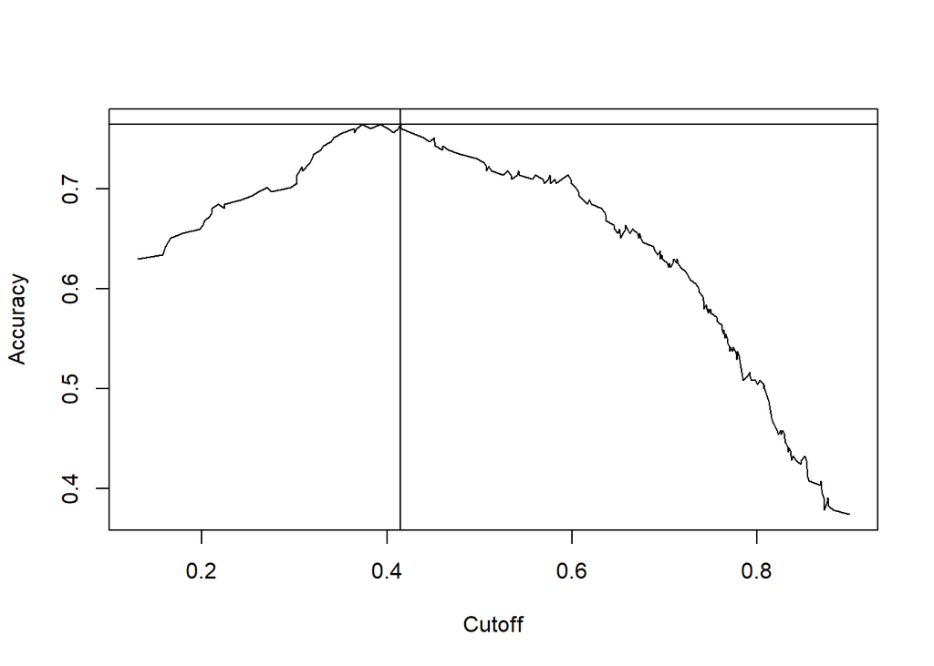

```r
prob_pred = predict(logistic_model, type = 'response', newdata = addicts[c(2, 4:6)])
prob_pred = prediction(prob_pred, addicts[3])
eval = performance(prob_pred, "acc")
plot(eval)
abline(h=0.7647059, v=0.4143900)
```

### 7. H. Identify best cut off values

```r
max = which.max(slot(eval, "y.values")[[1]])
acc = slot(eval, "y.values")[[1]][max]
cut = slot(eval, "x.values")[[1]][max]
print(c(accuracy=acc, cutoff=cut))
```

```
##   accuracy cutoff.196
##  0.7647059  0.4143900
```

### 7. I. Receiver Operating Characteric (ROC) Curve

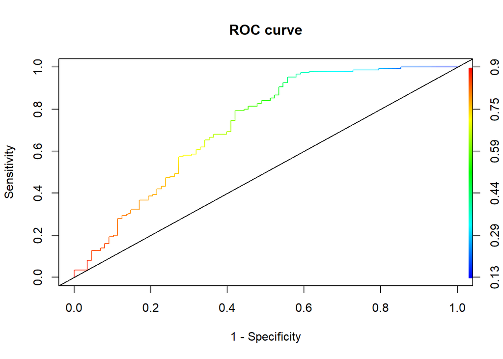

```r
prob_pred = predict(logistic_model, type = 'response', newdata = addicts[c(2, 4:6)])
prob_pred = prediction(prob_pred, addicts[3])
roc = performance(prob_pred, "tpr", "fpr")
plot(roc, colorize = T, main = "ROC curve", ylab = "Sensitivity", xlab = "1 - Specificity")
abline(a = 0, b = 1)
```

### 7. J. Area Under Curve (AUC)

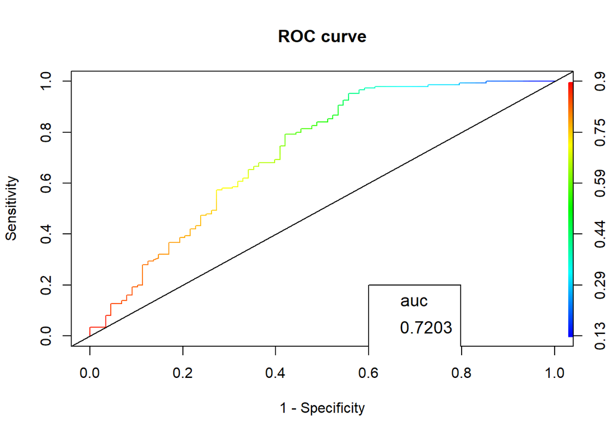

```r
prob_pred = predict(logistic_model, type = 'response', newdata = addicts[c(2, 4:6)])
prob_pred = prediction(prob_pred, addicts[3])
roc = performance(prob_pred, "tpr", "fpr")
plot(roc, colorize = T, main = "ROC curve", ylab = "Sensitivity", xlab = "1 - Specificity")
abline(a = 0, b = 1)
auc = performance(prob_pred, "auc")
auc = unlist(slot(auc, "y.values"))
auc = round(auc, 4)
legend(0.6, 0.2, auc, title = "auc", cex = 1.2)
```

### 7. K. Create a logistic regression model with optimal cut-off

#### 7. K. I. Predicting the results

```r
prob_pred = predict(logistic_model, type = 'response', newdata = addicts[c(2, 4:6)])
y_pred = ifelse(prob_pred > 0.4143900, 1, 0)
```

#### 7. K. II. Making the Confusion Matrix

```r
cm = table(addicts[,3], y_pred > 0.5)
cm
```

```
##
##     FALSE TRUE
##   0    39   49
##   1     7  143
```

#### 7. K. III. Accuracy Measures

```r
accuracy = sum(cm[1], cm[4]) / sum(cm[1:4])
print(paste(c("accuracy:", accuracy)))
```

```
## [1] "accuracy:"         "0.764705882352941"
```

```r
precision = cm[4] / sum(cm[4], cm[2])
print(paste(c("precision:", precision)))
```

```
## [1] "precision:"        "0.953333333333333"
```

```r
sensitivity <- cm[4] / sum(cm[4], cm[3])
print(paste(c("sensitivity:", sensitivity)))
```

```
## [1] "sensitivity:"      "0.744791666666667"
```

```r
specificity = cm[1] / sum(cm[1], cm[2])
print(paste(c("specificity:", specificity)))
```

```
## [1] "specificity:"      "0.847826086956522"
```

```r
fscore = (2 * (sensitivity * precision))/(sensitivity + precision)
print(paste(c("fscore:", fscore)))
```

```
## [1] "fscore:"          "0.83625730994152"
```

## 8. Creating a survival object

```r
Surv(addicts$survt,addicts$status==1)
```

```
##   [1]  428   275   262   183   259   714   438   796+  892   393   161+  836
##  [13]  523   612   212   399   771   514   512   624   209   341   299   826+
##  [25]  262   566+  368   302   602+  652   293   564+  394   755   591   787+
##  [37]  739   550   837   612   581+  523   504   785   774   560   160   482
##  [49]  518   683   147   563   646   899   857   180   452   760   496   258
##  [61]  181   386   439+  563+  337   613+  192   405+  667   905+  247   821
##  [73]  821   517+  346+  294   244    95   376   212    96   532   522   679
##  [85]  408+  840+  148+  168   489   541+  205   475+  237   517   749   150
##  [97]  465   708   713+  146+  450   555+  460    53+  122    35   532+  684+
## [109]  769+  591+  769+  609+  932+  932+  587+   26    72+  641+  367+  633+
## [121]  661   232    13   563+  969+ 1052+  944+  881+  190    79   884+  170
## [133]  286   358+  326+  769+  161   564+  268   611+  322  1076+    2+  788+
## [145]  575+  109   730+  790+  456+  231   143    86+ 1021+  684+  878   216
## [157]  808+  268   222+  683+  496+  389   126    17   350   531+  317+  461+
## [169]   37   167   358    49   457   127     7    29    62   150+  223   129+
## [181]  204+  129   581   176    30    41   543+  210+  193   434   367   348
## [193]   28+  337+  175+  149   546    84   283+  533   207   216    28+   67
## [205]   62+  111+  257   136   342+   41   531+   98+  145    50    53+  103+
## [217]    2+  157    75    19    35   394+  117   175   180   314   480+  325+
## [229]  280   204   366   531+   59    33   540   551+   90    47
```

## 9. Estimating survival functions (unadjusted) and comparing them across strata

### 9. A. Survival table

```r
summary(survfit(Surv(addicts$survt,addicts$status==1)~1))
```

```
## Call: survfit(formula = Surv(addicts$survt, addicts$status == 1) ~
##     1)
##
##  time n.risk n.event survival std.err lower 95% CI upper 95% CI
##     7    236       1    0.996 0.00423       0.9875        1.000
##    13    235       1    0.992 0.00597       0.9799        1.000
##    17    234       1    0.987 0.00729       0.9731        1.000
##    19    233       1    0.983 0.00840       0.9667        1.000
##    26    232       1    0.979 0.00937       0.9606        0.997
##    29    229       1    0.975 0.01026       0.9546        0.995
##    30    228       1    0.970 0.01107       0.9488        0.992
##    33    227       1    0.966 0.01182       0.9431        0.989
##    35    226       2    0.957 0.01317       0.9320        0.984
##    37    224       1    0.953 0.01379       0.9265        0.981
##    41    223       2    0.945 0.01493       0.9158        0.974
```

[output cut: 129 more lines]

### 9. B. Median Survival time in days in the addicts data set

```r
Y=Surv(addicts$survt,addicts$status==1)
Y~1
```

```
## Y ~ 1
```

```r
Y~addicts$clinic
```

```
## Y ~ addicts$clinic
```

```r
kmfit1=survfit(Y~1)
kmfit1
```

```
## Call: survfit(formula = Y ~ 1)
##
##        n events median 0.95LCL 0.95UCL
## [1,] 238    150    504     399     560
```

### 9. C. 1 year Survival rate

```r
summary(kmfit1)
```

```
## Call: survfit(formula = Y ~ 1)
##
##  time n.risk n.event survival std.err lower 95% CI upper 95% CI
##     7    236       1    0.996 0.00423       0.9875        1.000
##    13    235       1    0.992 0.00597       0.9799        1.000
##    17    234       1    0.987 0.00729       0.9731        1.000
##    19    233       1    0.983 0.00840       0.9667        1.000
##    26    232       1    0.979 0.00937       0.9606        0.997
##    29    229       1    0.975 0.01026       0.9546        0.995
##    30    228       1    0.970 0.01107       0.9488        0.992
##    33    227       1    0.966 0.01182       0.9431        0.989
##    35    226       2    0.957 0.01317       0.9320        0.984
##    37    224       1    0.953 0.01379       0.9265        0.981
##    41    223       2    0.945 0.01493       0.9158        0.974
##    47    221       1    0.940 0.01546       0.9105        0.971
```

[output cut: 128 more lines]

```r
summary(kmfit1,times=365)
```

```
## Call: survfit(formula = Y ~ 1)
##
##  time n.risk n.event survival std.err lower 95% CI upper 95% CI
##   365    122      87    0.606  0.0331        0.545        0.675
```

### 9. D. Survival rates incremented in 100 day increments

```r
kmfit2=survfit(Y~addicts$clinic)
summary(kmfit2,times=c(0,100,200,300,400,500,600,700,800,900,1000))
```

```
## Call: survfit(formula = Y ~ addicts$clinic)
##
##                 addicts$clinic=1
##  time n.risk n.event survival std.err lower 95% CI upper 95% CI
##     0    163       0   1.0000  0.0000      1.00000        1.000
##   100    137      20   0.8746  0.0262      0.82467        0.928
##   200    110      20   0.7420  0.0353      0.67601        0.814
##   300     87      20   0.6046  0.0399      0.53120        0.688
##   400     68      14   0.5025  0.0415      0.42741        0.591
##   500     53       9   0.4319  0.0418      0.35719        0.522
##   600     30      16   0.2951  0.0403      0.22570        0.386
##   700     20       8   0.2113  0.0383      0.14818        0.301
##   800     10       8   0.1268  0.0326      0.07660        0.210
##   900      1       7   0.0181  0.0172      0.00283        0.116
##
##                 addicts$clinic=2
##  time n.risk n.event survival std.err lower 95% CI upper 95% CI
##     0     75       0    1.000  0.0000        1.000        1.000
##   100     66       5    0.932  0.0294        0.876        0.991
##   200     58       7    0.832  0.0442        0.750        0.924
##   300     50       7    0.730  0.0530        0.633        0.842
##   400     43       3    0.685  0.0558        0.584        0.804
##   500     39       2    0.653  0.0577        0.549        0.776
##   600     27       1    0.634  0.0590        0.528        0.761
##   700     19       1    0.606  0.0625        0.495        0.742
##   800     11       1    0.575  0.0669        0.457        0.722
##   900      7       1    0.517  0.0812        0.380        0.703
##  1000      3       0    0.517  0.0812        0.380        0.703
```

```r
summary(kmfit2,times=100*(0:10))
```

```
## Call: survfit(formula = Y ~ addicts$clinic)
##
##                 addicts$clinic=1
##  time n.risk n.event survival std.err lower 95% CI upper 95% CI
##     0    163       0   1.0000  0.0000      1.00000        1.000
##   100    137      20   0.8746  0.0262      0.82467        0.928
##   200    110      20   0.7420  0.0353      0.67601        0.814
##   300     87      20   0.6046  0.0399      0.53120        0.688
##   400     68      14   0.5025  0.0415      0.42741        0.591
##   500     53       9   0.4319  0.0418      0.35719        0.522
##   600     30      16   0.2951  0.0403      0.22570        0.386
##   700     20       8   0.2113  0.0383      0.14818        0.301
##   800     10       8   0.1268  0.0326      0.07660        0.210
##   900      1       7   0.0181  0.0172      0.00283        0.116
##
##                 addicts$clinic=2
##  time n.risk n.event survival std.err lower 95% CI upper 95% CI
##     0     75       0    1.000  0.0000        1.000        1.000
##   100     66       5    0.932  0.0294        0.876        0.991
##   200     58       7    0.832  0.0442        0.750        0.924
##   300     50       7    0.730  0.0530        0.633        0.842
##   400     43       3    0.685  0.0558        0.584        0.804
##   500     39       2    0.653  0.0577        0.549        0.776
##   600     27       1    0.634  0.0590        0.528        0.761
##   700     19       1    0.606  0.0625        0.495        0.742
##   800     11       1    0.575  0.0669        0.457        0.722
##   900      7       1    0.517  0.0812        0.380        0.703
##  1000      3       0    0.517  0.0812        0.380        0.703
```

### 9. E. Plot Non-Parametric (KM) survival curves

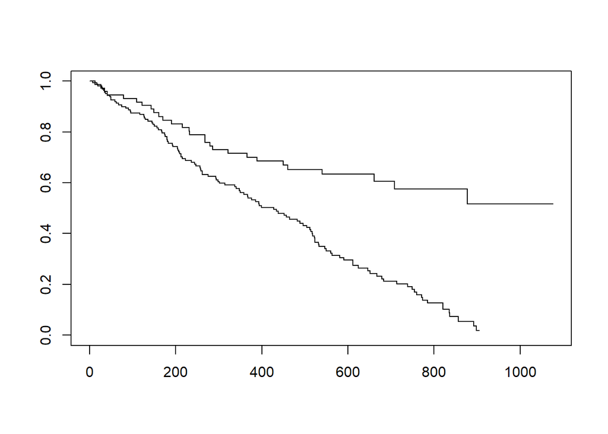

```r
plot(kmfit2)
```

### 9. F. Plot Non-Parametric (KM) survival curves in distinguishing colours

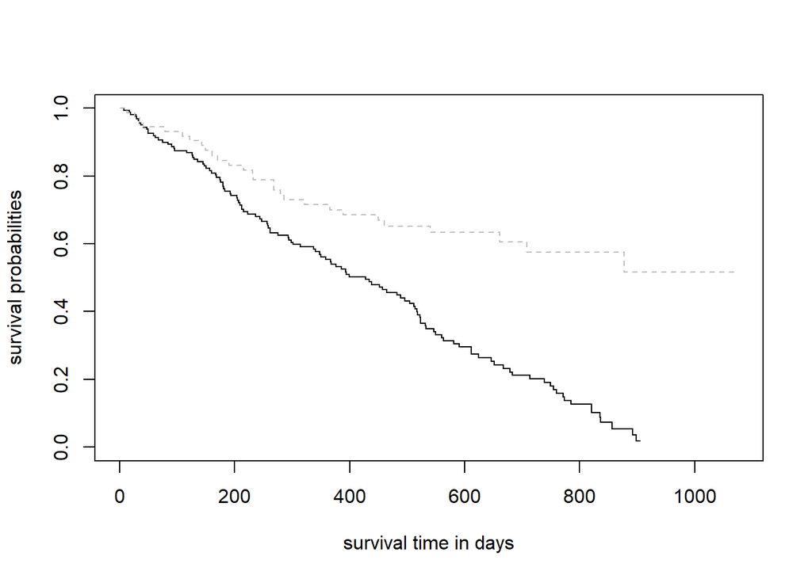

```r
plot(kmfit2, lty=c("solid", "dashed"), col=c("black","grey"),
     xlab="survival time in days", ylab="survival probabilities")
```

### 9. G. Plot Non-Parametric (KM) survival curves in distinguishing colours

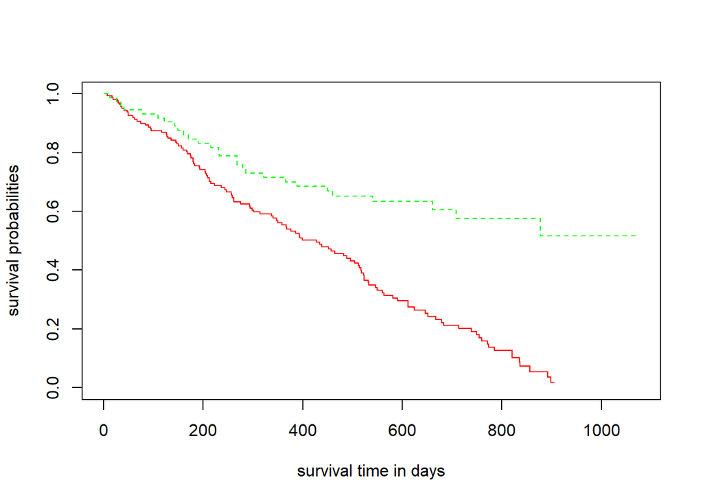

```r
plot(kmfit2, lty = c("solid", "dashed"), col=c("red","green"),
     xlab="survival time in days", ylab="survival probabilities")
```

### 9. H. Detecting significant difference between the two clinic groups

```r
survdiff(Surv(survt,status)~clinic, data=addicts)
```

```
## Call:
## survdiff(formula = Surv(survt, status) ~ clinic, data = addicts)
##
##            N Observed Expected (O-E)^2/E (O-E)^2/V
## clinic=1 163      122     90.9      10.6      27.9
## clinic=2  75       28     59.1      16.4      27.9
##
##  Chisq= 27.9  on 1 degrees of freedom, p= 1e-07
```

### 9. I. Attaching and detaching survival object to the data set addicts

```r
attach(addicts)
survdiff(Surv(survt,status)~clinic)
```

```
## Call:
## survdiff(formula = Surv(survt, status) ~ clinic)
##
##            N Observed Expected (O-E)^2/E (O-E)^2/V
## clinic=1 163      122     90.9      10.6      27.9
## clinic=2  75       28     59.1      16.4      27.9
##
##  Chisq= 27.9  on 1 degrees of freedom, p= 1e-07
```

```r
detach(addicts)
```

### 9. J. Detecting significant difference between the two clinic groups

```r
survdiff(Surv(survt,status)~clinic,data=addicts,rho = 1)
```

```
## Call:
## survdiff(formula = Surv(survt, status) ~ clinic, data = addicts,
##     rho = 1)
##
##            N Observed Expected (O-E)^2/E (O-E)^2/V
## clinic=1 163     77.3     61.4      4.08      15.8
## clinic=2  75     19.9     35.7      7.03      15.8
##
##  Chisq= 15.8  on 1 degrees of freedom, p= 7e-05
```

### 9. K. Detecting significant difference between the two clinic groups with prison as stratification

```r
survdiff(Surv(survt,status)~clinic + strata(prison),data=addicts)
```

```
## Call:
## survdiff(formula = Surv(survt, status) ~ clinic + strata(prison),
##     data = addicts)
##
##            N Observed Expected (O-E)^2/E (O-E)^2/V
## clinic=1 163      122     91.7      10.0      26.9
## clinic=2  75       28     58.3      15.8      26.9
##
##  Chisq= 26.9  on 1 degrees of freedom, p= 2e-07
```

## 10. Assessing the PH assumption using graphical approaches

### 10. A. Plot of Log-log curvers vs log time for the two clinics

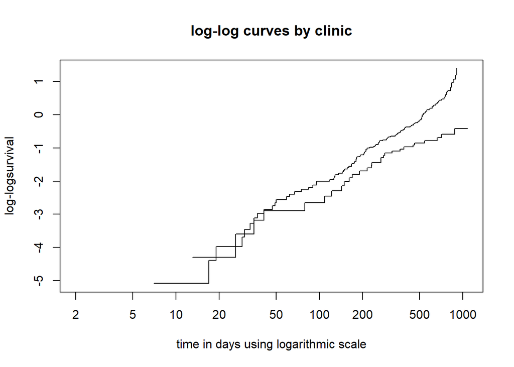

```r
plot(kmfit2,fun="cloglog",xlab = "time in days using logarithmic scale",
     ylab = "log-logsurvival",main="log-log curves by clinic")
```

### 10. B. Construct a data frame of clinic, time and survival probability

```r
kmfit3=summary(kmfit2)
names(kmfit3)
```

```
##  [1] "n"             "time"          "n.risk"        "n.event"
##  [5] "n.censor"      "surv"          "std.err"       "cumhaz"
##  [9] "std.chaz"      "strata"        "type"          "logse"
## [13] "conf.int"      "conf.type"     "lower"         "upper"
## [17] "t0"            "call"          "table"         "rmean.endtime"
```

```r
kmfit4=data.frame(kmfit3$strata,kmfit3$time,kmfit3$surv)
names(kmfit4)=c("clinic","time","survival")

kmfit4[1:5,]
```

```
##             clinic time  survival
## 1 addicts$clinic=1    7 0.9938272
## 2 addicts$clinic=1   17 0.9876543
## 3 addicts$clinic=1   19 0.9814815
## 4 addicts$clinic=1   29 0.9752300
## 5 addicts$clinic=1   30 0.9689785
```

### 10. C. Split the dataframe into separate dataframes for the two clinics

```r
clinic1=kmfit4[kmfit4$clinic=="addicts$clinic=1",]
clinic2=kmfit4[kmfit4$clinic=="addicts$clinic=2",]

clinic1[1:5,]
```

```
##             clinic time  survival
## 1 addicts$clinic=1    7 0.9938272
## 2 addicts$clinic=1   17 0.9876543
## 3 addicts$clinic=1   19 0.9814815
## 4 addicts$clinic=1   29 0.9752300
## 5 addicts$clinic=1   30 0.9689785
```

```r
clinic2[1:5,]
```

```
##               clinic time  survival
## 117 addicts$clinic=2   13 0.9864865
## 118 addicts$clinic=2   26 0.9729730
## 119 addicts$clinic=2   35 0.9594595
## 120 addicts$clinic=2   41 0.9459459
## 121 addicts$clinic=2   79 0.9320350
```

### 10. D. Overlay plot log-log survival time vs survival time for the two clinics

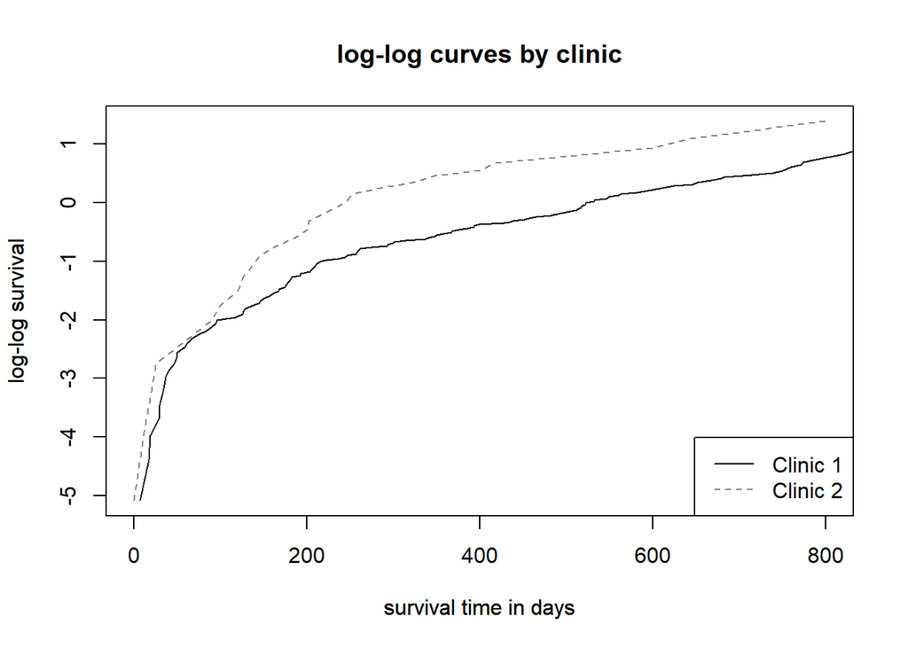

```r
plot(clinic1$time,log(-log(clinic1$survival)),
     xlab = "survival time in days",ylab = "log-log survival",
     xlim=c(0,800),col="black",type='l',lty="solid",main="log-log curves by clinic")

par(new=T)
plot(clinic2$time,log(-log(clinic2$survival)),axes=F,xlab = "survival time in days",
     ylab="log-log survival",col="grey50",type='l',lty="dashed")

legend("bottomright",c("Clinic 1","Clinic 2"),
       lty = c("solid","dashed"),col = c("black","grey50"))
```

## 11. Running a COX PH model

### 11. A. Creating a COX PH model

```r
Y=Surv(addicts$survt,addicts$status==1)

coxph(Y~prison + dose + clinic,data=addicts)
```

```
## Call:
## coxph(formula = Y ~ prison + dose + clinic, data = addicts)
##
##             coef exp(coef)  se(coef)      z        p
## prison  0.326555  1.386184  0.167225  1.953   0.0508
## dose   -0.035369  0.965249  0.006379 -5.545 2.94e-08
## clinic -1.009896  0.364257  0.214889 -4.700 2.61e-06
##
## Likelihood ratio test=64.56  on 3 df, p=6.229e-14
## n= 238, number of events= 150
```

### 11. B. Detailed COX PH model

```r
summary(coxph(Y~prison+dose+clinic,data=addicts))
```

```
## Call:
## coxph(formula = Y ~ prison + dose + clinic, data = addicts)
##
##   n= 238, number of events= 150
##
##             coef exp(coef)  se(coef)      z Pr(>|z|)
## prison  0.326555  1.386184  0.167225  1.953   0.0508 .
## dose   -0.035369  0.965249  0.006379 -5.545 2.94e-08 ***
## clinic -1.009896  0.364257  0.214889 -4.700 2.61e-06 ***
## ---
## Signif. codes:  0 '***' 0.001 '**' 0.01 '*' 0.05 '.' 0.1 ' ' 1
##
##        exp(coef) exp(-coef) lower .95 upper .95
## prison    1.3862     0.7214    0.9988    1.9238
## dose      0.9652     1.0360    0.9533    0.9774
## clinic    0.3643     2.7453    0.2391    0.5550
##
## Concordance= 0.665  (se = 0.025 )
## Likelihood ratio test= 64.56  on 3 df,   p=6e-14
## Wald test            = 54.12  on 3 df,   p=1e-11
## Score (logrank) test = 56.32  on 3 df,   p=4e-12
```

### 11. C. Handling ties (i.e. more than one event in a defined time interval) - several methods

```r
coxph(Y~prison + dose + clinic,data=addicts, method="efron")
```

```
## Call:
## coxph(formula = Y ~ prison + dose + clinic, data = addicts, method = "efron")
##
##             coef exp(coef)  se(coef)      z        p
## prison  0.326555  1.386184  0.167225  1.953   0.0508
## dose   -0.035369  0.965249  0.006379 -5.545 2.94e-08
## clinic -1.009896  0.364257  0.214889 -4.700 2.61e-06
##
## Likelihood ratio test=64.56  on 3 df, p=6.229e-14
## n= 238, number of events= 150
```

```r
coxph(Y~prison + dose + clinic,data=addicts, method="breslow")
```

```
## Call:
## coxph(formula = Y ~ prison + dose + clinic, data = addicts, method = "breslow")
##
##             coef exp(coef)  se(coef)      z        p
## prison  0.326511  1.386123  0.167221  1.953   0.0509
## dose   -0.035396  0.965223  0.006379 -5.548 2.88e-08
## clinic -1.008870  0.364631  0.214871 -4.695 2.66e-06
##
## Likelihood ratio test=64.52  on 3 df, p=6.357e-14
## n= 238, number of events= 150
```

```r
coxph(Y~prison + dose + clinic,data=addicts, method="exact")
```

```
## Call:
## coxph(formula = Y ~ prison + dose + clinic, data = addicts, method = "exact")
##
##             coef exp(coef)  se(coef)      z        p
## prison  0.326969  1.386758  0.167422  1.953   0.0508
## dose   -0.035466  0.965155  0.006387 -5.553 2.81e-08
## clinic -1.010799  0.363928  0.215070 -4.700 2.60e-06
##
## Likelihood ratio test=64.63  on 3 df, p=6.012e-14
## n= 238, number of events= 150
```

### 11. D. Testing the significance of interactions - mod 1 - the reduced model

```r
mod1=coxph(Y~prison + dose + clinic,data=addicts)
mod1
```

```
## Call:
## coxph(formula = Y ~ prison + dose + clinic, data = addicts)
##
##             coef exp(coef)  se(coef)      z        p
## prison  0.326555  1.386184  0.167225  1.953   0.0508
## dose   -0.035369  0.965249  0.006379 -5.545 2.94e-08
## clinic -1.009896  0.364257  0.214889 -4.700 2.61e-06
##
## Likelihood ratio test=64.56  on 3 df, p=6.229e-14
## n= 238, number of events= 150
```

### 11. E. Testing the significance of interactions - mod 2 - the full model

```r
mod2=coxph(Y~prison + dose + clinic + clinic*prison + clinic*dose, data=addicts)
mod2
```

```
## Call:
## coxph(formula = Y ~ prison + dose + clinic + clinic * prison +
##     clinic * dose, data = addicts)
##
##                   coef exp(coef) se(coef)      z      p
## prison         1.19238   3.29491  0.54141  2.202 0.0276
## dose          -0.01916   0.98102  0.01935 -0.990 0.3220
## clinic         0.17955   1.19668  0.89330  0.201 0.8407
## prison:clinic -0.73832   0.47791  0.43151 -1.711 0.0871
## dose:clinic   -0.01396   0.98614  0.01433 -0.974 0.3300
##
## Likelihood ratio test=68.18  on 5 df, p=2.452e-13
## n= 238, number of events= 150
```

### 11. F. Utilising information from mod 1 and mod 2

```r
names(mod2)
```

```
##  [1] "coefficients"      "var"               "loglik"
##  [4] "score"             "iter"              "linear.predictors"
##  [7] "residuals"         "means"             "method"
## [10] "n"                 "nevent"            "terms"
## [13] "assign"            "wald.test"         "concordance"
## [16] "y"                 "timefix"           "formula"
## [19] "call"
```

### 11. G. Call up the log-likelihood function

```r
# first term = model with no predictors, second term model with predictors
mod2$loglik
```

```
## [1] -705.5393 -671.4500
```

```r
# or
mod2[[3]]
```

```
## [1] -705.5393 -671.4500
```

### 11. H. Calculate the difference in -2 Log-likelihood (deviance) of the two models

```r
(-2)*(mod1$loglik[2]-mod2$loglik[2])
```

```
## [1] 3.618211
```

### 11. I. Determine the significance of the difference between the models using Chi-square statistic

```r
LRT=(-2)*(mod1$loglik[2]-mod2$loglik[2])
Pvalue = 1 - pchisq(LRT,2)
Pvalue
```

```
## [1] 0.1638006
```

### 11. K. Determine the significance of the difference between models using a self-defined function.

```r
lrt.surv=function(mod.full,mod.reduced,df){
  lrts=(-2)*(mod.full$loglik[2]-mod.reduced$loglik[2])
  pvalue=1-pchisq(lrts,df)
  return(pvalue)
}

lrt.surv(mod1,mod2, 2)
```

```
## [1] 0.1638006
```

## 12. Running a stratified Cox model

### 12. A. Creating a stratified Cox model

```r
Y=Surv(addicts$survt,addicts$status==1)
coxph(Y~ prison + dose + strata(clinic),data = addicts)
```

```
## Call:
## coxph(formula = Y ~ prison + dose + strata(clinic), data = addicts)
##
##             coef exp(coef)  se(coef)      z        p
## prison  0.389605  1.476397  0.168930  2.306   0.0211
## dose   -0.035115  0.965495  0.006465 -5.432 5.59e-08
##
## Likelihood ratio test=33.91  on 2 df, p=4.322e-08
## n= 238, number of events= 150
```

### 12. B. Including interaction term in a stratified Cox model

```r
coxph(Y~prison + dose + clinic:prison + clinic:dose + strata(clinic),data=addicts)
```

```
## Call:
## coxph(formula = Y ~ prison + dose + clinic:prison + clinic:dose +
##     strata(clinic), data = addicts)
##
##                    coef exp(coef)  se(coef)      z      p
## prison         1.085836  2.961914  0.538636  2.016 0.0438
## dose          -0.034635  0.965958  0.019797 -1.750 0.0802
## prison:clinic -0.582989  0.558227  0.428135 -1.362 0.1733
## dose:clinic   -0.001164  0.998837  0.014570 -0.080 0.9363
##
## Likelihood ratio test=35.77  on 4 df, p=3.222e-07
## n= 238, number of events= 150
```

### 12. C. Estimating hazard ratio for PRISON=1 vs PRISON=0 for CLINIC=2

```r
addicts$clinic2=addicts$clinic-2
summary(coxph(Y~prison + dose + clinic2:prison +
                clinic2:dose+strata(clinic2),data=addicts))
```

```
## Call:
## coxph(formula = Y ~ prison + dose + clinic2:prison + clinic2:dose +
##     strata(clinic2), data = addicts)
##
##   n= 238, number of events= 150
##
##                     coef exp(coef)  se(coef)      z Pr(>|z|)
## prison         -0.080143  0.922985  0.384305 -0.209  0.83481
## dose           -0.036964  0.963711  0.012346 -2.994  0.00275 **
## prison:clinic2 -0.582989  0.558227  0.428135 -1.362  0.17329
## dose:clinic2   -0.001164  0.998837  0.014570 -0.080  0.93632
## ---
## Signif. codes:  0 '***' 0.001 '**' 0.01 '*' 0.05 '.' 0.1 ' ' 1
##
##                exp(coef) exp(-coef) lower .95 upper .95
## prison            0.9230      1.083    0.4346    1.9603
## dose              0.9637      1.038    0.9407    0.9873
## prison:clinic2    0.5582      1.791    0.2412    1.2919
## dose:clinic2      0.9988      1.001    0.9707    1.0278
##
## Concordance= 0.649  (se = 0.026 )
## Likelihood ratio test= 35.77  on 4 df,   p=3e-07
## Wald test            = 34.09  on 4 df,   p=7e-07
## Score (logrank) test = 34.97  on 4 df,   p=5e-07
```

## 13. Assessing the PH assumption with a statistical test

### 13. A. Creating the model

```r
Y=Surv(addicts$survt,addicts$status==1)
mod1=coxph(Y~prison + dose + clinic,data=addicts)

cox.zph(mod1,transform=rank)
```

```
##         chisq df       p
## prison  0.853  1 0.35567
## dose    0.608  1 0.43557
## clinic 11.302  1 0.00077
## GLOBAL 12.465  3 0.00595
```

### 13. B. Plot of Schoenfeld residuals against each individual’s failure time.

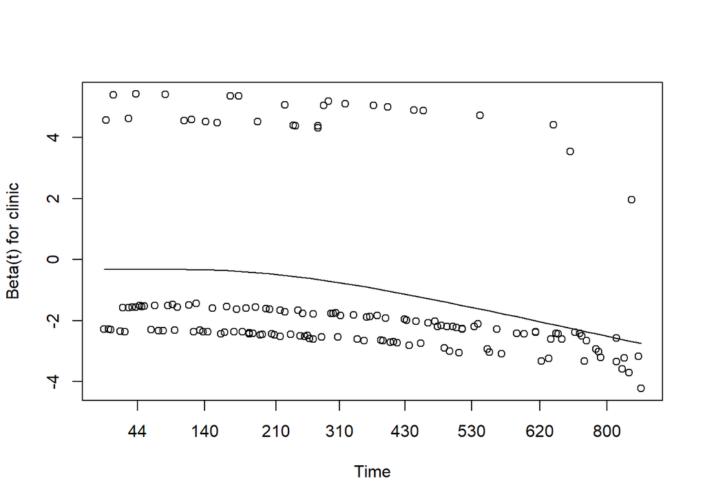

```r
plot(cox.zph(mod1,transform=rank),se=F,var='clinic')
```

### 13. C. Obtaining Cox-adjusted survival curves - Run Cox unadjusted model

```r
Y=Surv(addicts$survt,addicts$status==1)
mod1=coxph(Y~prison + dose + clinic, data=addicts)
```

### 13. D. Obtaining Cox-adjusted survival curves - Adjusted Cox model with the adjustments as follows

```r
# PRISON = 0, DOSE=70 AND CLINIC=2
# CREATE DATA FRAME FIRST

pattern1=data.frame(prison=0,dose=70,clinic=2)

pattern1
```

```
##   prison dose clinic
## 1      0   70      2
```

### 13. E. Use summary function to get the Cox adjusted survival estimates

```r
summary(survfit(mod1,newdata=pattern1))
```

```
## Call: survfit(formula = mod1, newdata = pattern1)
##
##  time n.risk n.event survival std.err lower 95% CI upper 95% CI
##     7    236       1    0.999 0.00105        0.997        1.000
##    13    235       1    0.998 0.00154        0.995        1.000
##    17    234       1    0.997 0.00193        0.993        1.000
##    19    233       1    0.996 0.00229        0.991        1.000
##    26    232       1    0.995 0.00263        0.990        1.000
##    29    229       1    0.994 0.00296        0.988        1.000
##    30    228       1    0.993 0.00328        0.986        0.999
##    33    227       1    0.992 0.00359        0.985        0.999
##    35    226       2    0.989 0.00419        0.981        0.998
##    37    224       1    0.988 0.00448        0.980        0.997
##    41    223       2    0.986 0.00506        0.976        0.996
##    47    221       1    0.985 0.00535        0.975        0.996
```

[output cut: 128 more lines]

### 13. F. Plot of the adjusted survival curve

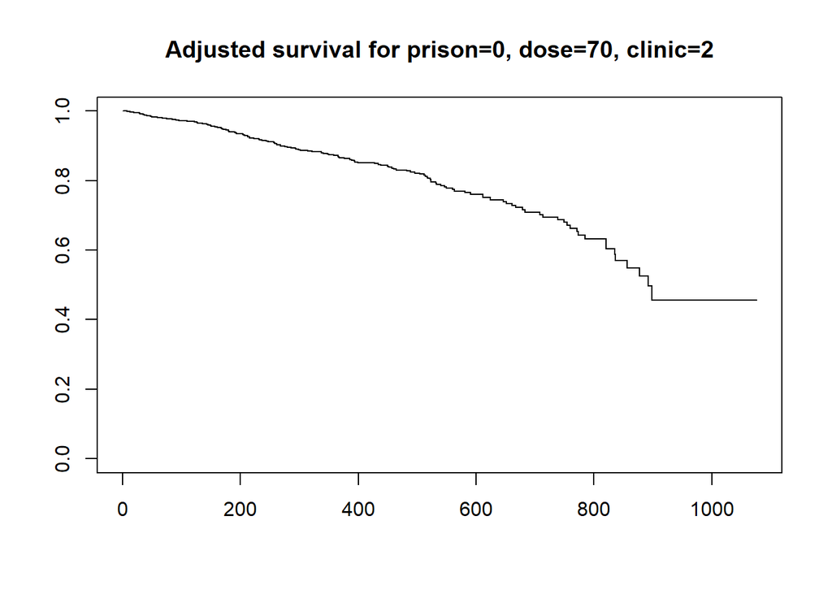

```r
plot(survfit(mod1, newdata=pattern1),
     conf.int=F,main="Adjusted survival for prison=0, dose=70, clinic=2")
```

### 13. G. Stratified Cox adjusted survival curves - stratified cox model

```r
mod3=coxph(Y~prison + dose + strata(clinic),data=addicts)
```

### 13. H. stratified cox model controlling for PRISON and DOSE

```r
# Creation of one observation data frame, with the mean for prison
# and dose.
pattern2=data.frame(prison=0.46,dose=60.40)
```

### 13. I. Plotting adjusted survival curve with clinic as the strata

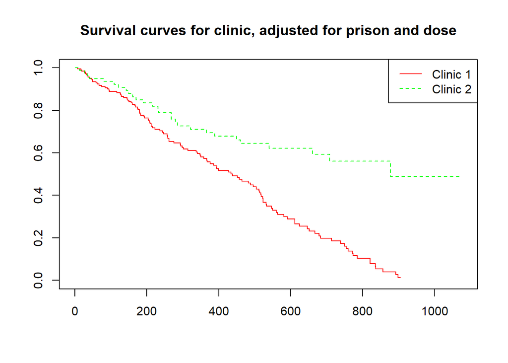

```r
plot(survfit(mod3,newdata=pattern2), conf.int=F, lty=c("solid","dashed"),
     col=c("red","green"), main="Survival curves for clinic, adjusted for prison and dose")
legend("topright",c("Clinic 1","Clinic 2"),lty=c("solid","dashed"), col=c("red","green"))
```

### 13. J. Plotting adjusted log-log survival curves for clinic

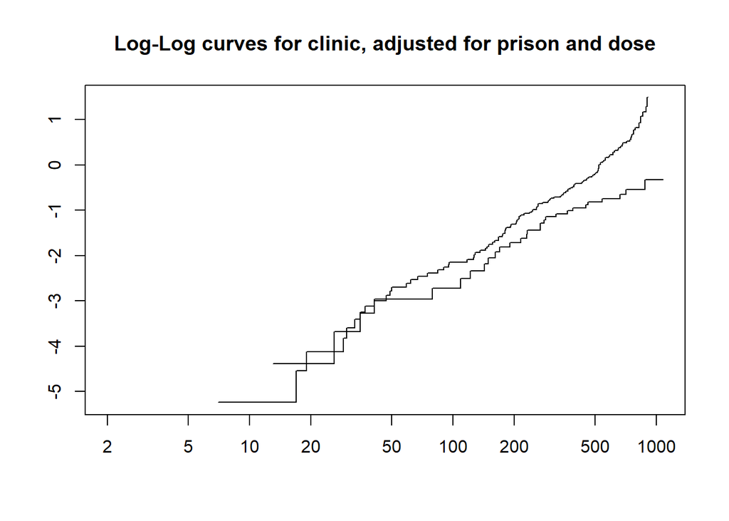

```r
plot(survfit(mod3,newdata = pattern2),fun="cloglog",
     main="Log-Log curves for clinic, adjusted for prison and dose")
```

### 13. K. Plotting adjusted log-log survival curves for clinic with the time scale not logged

```r
sum.mod3=summary(survfit(mod3,newdata=pattern2))

sum.mod4=data.frame(sum.mod3$strata,sum.mod3$time,sum.mod3$surv)
colnames(sum.mod4)=c("clinic","time","survival")
clinic1=sum.mod4[sum.mod4$clinic=="clinic=1",]
clinic2=sum.mod4[sum.mod4$clinic=="clinic=2",]
```

### 13. L. Plot log-log survival vs survival time

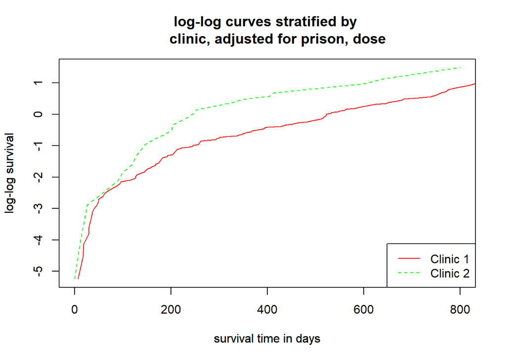

```r
plot(clinic1$time,log(-log(clinic1$survival)),xlab="survival time in days",ylab="log-log survival",xlim=c(0,800),col=
       "red",type='l',lty="solid", main="log-log curves stratified by
     clinic, adjusted for prison, dose")

par(new=T)

plot(clinic2$time,log(-log(clinic2$survival)),axes=F,xlab=
       "survival time in days",ylab="log-log survival",col="green",
     type='l',lty="dashed")

legend("bottomright",c("Clinic 1","Clinic 2"), lty=c("solid","dashed"),col=c("red","green"))
```

```r
par(new=F)
```

## 14. - Running an extended Cox Model

### 14. A. Transforming the dataset into counting process (start, stop) format to run an extended Cox model

```r
addicts.cp=survSplit(addicts,cut=addicts$survt[addicts$status==1],
                     end="survt", event="status",start="start")

nrow(addicts.cp)
```

```
## [1] 18708
```

### 14. B. Creation of a new variable

```r
addicts.cp$logtdose=addicts.cp$dose*log(addicts.cp$survt)
```

### 14. C. For the new variable

```r
addicts.cp[addicts.cp$id==106,c('id','start','survt','status','dose','logtdose')]
```

```
##       id start survt status dose logtdose
## 9459 106     0     7      0   55 107.0251
## 9460 106     7    13      0   55 141.0722
## 9461 106    13    17      0   55 155.8267
## 9462 106    17    19      0   55 161.9441
## 9463 106    19    26      0   55 179.1953
## 9464 106    26    29      0   55 185.2013
## 9465 106    29    30      0   55 187.0659
## 9466 106    30    33      0   55 192.3079
## 9467 106    33    35      0   55 195.5441
## 9468 106    35    37      0   55 198.6005
## 9469 106    37    41      0   55 204.2465
## 9470 106    41    47      0   55 211.7581
## 9471 106    47    49      0   55 214.0501
## 9472 106    49    50      0   55 215.1613
```

[output cut: 79 more lines]

### 14. D. Run the extended Cox model with the inclusion of predictors

PRISON, DOSE, and CLINIC, and time dependent variable LOGTDOSE

```r
coxph(Surv(addicts.cp$start,addicts.cp$survt,addicts.cp$status) ~
        prison + dose + clinic + logtdose + cluster(id),data=addicts.cp)
```

```
## Call:
## coxph(formula = Surv(addicts.cp$start, addicts.cp$survt, addicts.cp$status) ~
##     prison + dose + clinic + logtdose, data = addicts.cp, cluster = id)
##
##               coef exp(coef)  se(coef) robust se      z       p
## prison    0.340633  1.405837  0.167474  0.159717  2.133 0.03295
## dose     -0.082625  0.920696  0.035984  0.029601 -2.791 0.00525
## clinic   -1.019875  0.360640  0.215416  0.236365 -4.315 1.6e-05
## logtdose  0.008615  1.008652  0.006455  0.005248  1.642 0.10068
##
## Likelihood ratio test=66.35  on 4 df, p=1.338e-13
## n= 18708, number of events= 150
```

### 14. E. Running the extended Cox model with a time cutpoint of 365 days

Essentially splitting the time of the study into observations below 365 days and observations above 365 days

```r
addicts.cp365=survSplit(addicts,cut=365,end="survt", event="status",start="start")
```

### 14. F. Defining the timepoint 365 days and the two time intervals (heaviside functions) above and below 365 days

```r
addicts.cp365$hv1=addicts.cp365$clinic*(addicts.cp365$start<365)
addicts.cp365$hv2=addicts.cp365$clinic*(addicts.cp365$start>=365)
```

### 14. G. Sort the dataset by variables ID and START

```r
addicts.cp365=addicts.cp365[order(addicts.cp365$id,addicts.cp365$start),]
```

### 14. H. Printout of the first 10 observations for selected variables

```r
addicts.cp365[1:10,c('id','start', 'survt','status','clinic','hv1','hv2')]
```

```
##    id start survt status clinic hv1 hv2
## 1   1     0   365      0      1   1   0
## 2   1   365   428      1      1   0   1
## 3   2     0   275      1      1   1   0
## 4   3     0   262      1      1   1   0
## 5   4     0   183      1      1   1   0
## 6   5     0   259      1      1   1   0
## 7   6     0   365      0      1   1   0
## 8   6   365   714      1      1   0   1
## 9   7     0   365      0      1   1   0
## 10  7   365   438      1      1   0   1
```

### 14. I. Running an extended Cox model with heaviside functions (time intervals)

Define the object for the response variable

```r
Y365=Surv(addicts.cp365$start,addicts.cp365$survt,addicts.cp365$status)
```

### 14. J. Run the Cox extended model with the two heaviside functions

```r
coxph(Y365 ~ prison + dose + hv1 + hv2 + cluster(id), data=addicts.cp365)
```

```
## Call:
## coxph(formula = Y365 ~ prison + dose + hv1 + hv2, data = addicts.cp365,
##     cluster = id)
##
##             coef exp(coef)  se(coef) robust se      z        p
## prison  0.377951  1.459291  0.168415  0.167650  2.254   0.0242
## dose   -0.035480  0.965142  0.006435  0.006520 -5.442 5.27e-08
## hv1    -0.459373  0.631679  0.255290  0.259983 -1.767   0.0772
## hv2    -1.830517  0.160331  0.385954  0.398376 -4.595 4.33e-06
##
## Likelihood ratio test=74.25  on 4 df, p=2.868e-15
## n= 360, number of events= 150
```

### 14. K. Handling ties in the two different time intervals (heaviside functions)

```r
coxph(Y365 ~ prison + dose +hv1 + hv2,data=addicts.cp365,method="breslow")
```

```
## Call:
## coxph(formula = Y365 ~ prison + dose + hv1 + hv2, data = addicts.cp365,
##     method = "breslow")
##
##             coef exp(coef)  se(coef)      z        p
## prison  0.377704  1.458931  0.168402  2.243   0.0249
## dose   -0.035512  0.965112  0.006435 -5.518 3.43e-08
## hv1    -0.459563  0.631560  0.255291 -1.800   0.0718
## hv2    -1.828228  0.160698  0.385946 -4.737 2.17e-06
##
## Likelihood ratio test=74.17  on 4 df, p=2.978e-15
## n= 360, number of events= 150
```

### 14. L. Run Cox extended model with one heaviside function and the variable CLINIC

```r
coxph(Y365 ~ prison + dose + clinic + hv2 + cluster(id),data=addicts.cp365)
```

```
## Call:
## coxph(formula = Y365 ~ prison + dose + clinic + hv2, data = addicts.cp365,
##     cluster = id)
##
##             coef exp(coef)  se(coef) robust se      z        p
## prison  0.377951  1.459291  0.168415  0.167650  2.254  0.02417
## dose   -0.035480  0.965142  0.006435  0.006520 -5.442 5.27e-08
## clinic -0.459373  0.631679  0.255290  0.259983 -1.767  0.07724
## hv2    -1.371144  0.253816  0.461403  0.470540 -2.914  0.00357
##
## Likelihood ratio test=74.25  on 4 df, p=2.868e-15
## n= 360, number of events= 150
```

## 15. Running Parametric Models

### 15. A. log-log survival vs time in days using log-time plot

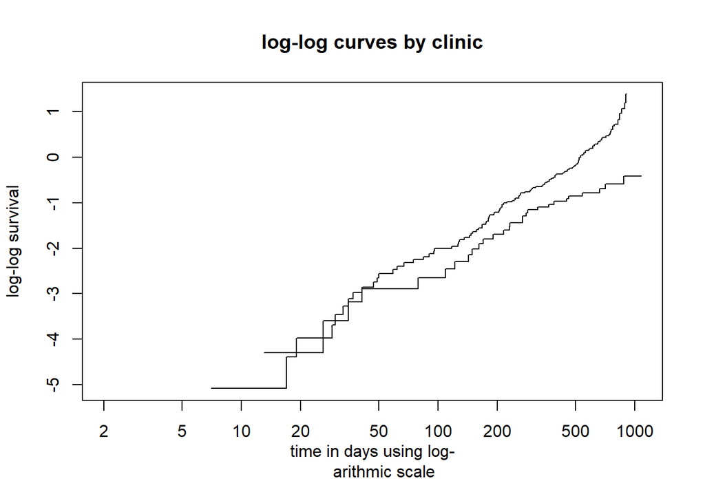

```r
plot(survfit(Y~addicts$clinic),fun="cloglog",xlab="time in days using log-
     arithmic scale",ylab="log-log survival", main="log-log curves by clinic")
```

### 15. B. Exponential AFT model

```r
modpar1=survreg(Surv(addicts$survt,addicts$status) ~ prison + dose +
                  clinic,data=addicts,dist="exponential")

summary(modpar1)
```

```
##
## Call:
## survreg(formula = Surv(addicts$survt, addicts$status) ~ prison +
##     dose + clinic, data = addicts, dist = "exponential")
##                Value Std. Error     z       p
## (Intercept)  3.68434    0.43072  8.55 < 2e-16
## prison      -0.25265    0.16489 -1.53    0.13
## dose         0.02892    0.00614  4.71 2.5e-06
## clinic       0.88058    0.21063  4.18 2.9e-05
##
## Scale fixed at 1
##
## Exponential distribution
## Loglik(model)= -1094   Loglik(intercept only)= -1118.9
##  Chisq= 49.91 on 3 degrees of freedom, p= 8.3e-11
## Number of Newton-Raphson Iterations: 5
## n= 238
```

### 15. C. Weibull AFT model

```r
modpar2=survreg(Surv(addicts$survt,addicts$status)
                ~ prison + dose + clinic,data=addicts,dist="weibull")

summary(modpar2)
```

```
##
## Call:
## survreg(formula = Surv(addicts$survt, addicts$status) ~ prison +
##     dose + clinic, data = addicts, dist = "weibull")
##                Value Std. Error     z       p
## (Intercept)  4.10485    0.32806 12.51 < 2e-16
## prison      -0.22947    0.12079 -1.90   0.057
## dose         0.02443    0.00459  5.32 1.0e-07
## clinic       0.70904    0.15722  4.51 6.5e-06
## Log(scale)  -0.31495    0.06756 -4.66 3.1e-06
##
## Scale= 0.73
##
## Weibull distribution
## Loglik(model)= -1084.5   Loglik(intercept only)= -1114.9
##  Chisq= 60.89 on 3 degrees of freedom, p= 3.8e-13
## Number of Newton-Raphson Iterations: 7
## n= 238
```

### 15. D. Use of predict function to estimate then median or any other quantile time to event

```r
# for any pattern of co-variates
# Co-variate pattern; PRISON=1, DOSE=50 AND CLINIC=1
pattern1=data.frame(prison=1,dose=50,clinic=1)
pct=c(0.25,0.50,0.75)
days=predict(modpar2,newdata=pattern1,type="quantile",p=pct)
cbind(pct,days) # adds vectors pct and days to create a matrix containing both vectors
```

```
##       pct     days
## [1,] 0.25 133.8074
## [2,] 0.50 254.2196
## [3,] 0.75 421.6070
```

### 15. E. Creating a plot for individual with covariate pattern

PRISON=1, DOSE=50 AND CLINIC=1

[figure not shown]

```r
pct2=0:100/100
days2=predict(modpar2,newdata=pattern1,type="quantile",p=pct2)
survival=1-pct2

plot(days2,survival,xlab="survival time in days",ylab="survival
     probabilities",main="Weibull survival estimates for prison=0,
     dose=50, clinic=1",xlim=c(0,800))
```

### 15. F. log-logistic AFT model

```r
modpar3=survreg(Surv(addicts$survt,addicts$status)~
                  prison + dose + clinic,data=addicts,dist="loglogistic")

summary(modpar3)
```

```
##
## Call:
## survreg(formula = Surv(addicts$survt, addicts$status) ~ prison +
##     dose + clinic, data = addicts, dist = "loglogistic")
##                Value Std. Error     z       p
## (Intercept)  3.56327    0.38945  9.15 < 2e-16
## prison      -0.29127    0.14396 -2.02 0.04305
## dose         0.03161    0.00552  5.73 1.0e-08
## clinic       0.58060    0.17157  3.38 0.00071
## Log(scale)  -0.53314    0.06863 -7.77 7.9e-15
##
## Scale= 0.587
##
## Log logistic distribution
## Loglik(model)= -1093.9   Loglik(intercept only)= -1120
##  Chisq= 52.18 on 3 degrees of freedom, p= 2.7e-11
## Number of Newton-Raphson Iterations: 4
## n= 238
```

### 15. G. Kaplan Meier (KM) estimates object

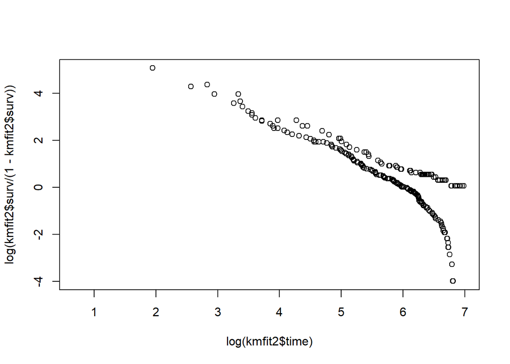

```r
kmfit2=survfit(Surv(addicts$survt,addicts$status)~addicts$clinic)

plot(log(kmfit2$time),log(kmfit2$surv/(1-kmfit2$surv)))
```

## 16 - Running Frailty Models

### 16. A. Re-run the stratified Cox model without the Frailty (random) component.

```r
Y=Surv(addicts$survt,addicts$status==1)
coxph(Y~ prison + dose + strata(clinic),data=addicts)
```

```
## Call:
## coxph(formula = Y ~ prison + dose + strata(clinic), data = addicts)
##
##             coef exp(coef)  se(coef)      z        p
## prison  0.389605  1.476397  0.168930  2.306   0.0211
## dose   -0.035115  0.965495  0.006465 -5.432 5.59e-08
##
## Likelihood ratio test=33.91  on 2 df, p=4.322e-08
## n= 238, number of events= 150
```

### 16. B. Run the stratified Cox model with Frailty (random) component.

```r
coxph(Y~ prison + dose + strata(clinic) + frailty(clinic,distribution="gamma"),data=addicts)
```

```
## Call:
## coxph(formula = Y ~ prison + dose + strata(clinic) + frailty(clinic,
##     distribution = "gamma"), data = addicts)
##
##                               coef se(coef)      se2    Chisq DF       p
## prison                     0.38960  0.16893  0.16893  5.31907  1   0.021
## dose                      -0.03511  0.00646  0.00646 29.50201  1 5.6e-08
## frailty(clinic, distribut                             0.00000  0   1.000
##
## Iterations: 6 outer, 8 Newton-Raphson
##      Variance of random effect= 5e-07   I-likelihood = -597.5
## Degrees of freedom for terms= 1 1 0
## Likelihood ratio test=33.9  on 2 df, p=4e-08
## n= 238, number of events= 150
```

### 16. C. Run the Cox model without the CLINIC variable and without FRAILTY.

```r
coxph(Y~ prison + dose,data=addicts)
```

```
## Call:
## coxph(formula = Y ~ prison + dose, data = addicts)
##
##            coef exp(coef) se(coef)      z        p
## prison  0.18965   1.20883  0.16427  1.155    0.248
## dose   -0.03608   0.96457  0.00600 -6.013 1.83e-09
##
## Likelihood ratio test=38.21  on 2 df, p=5.045e-09
## n= 238, number of events= 150
```

### 16. D. Run the Cox model without the CLINIC variable and with FRAILTY

```r
coxph(Y~ prison + dose + frailty(clinic,distribution="gamma"),data=addicts)
```

```
## Call:
## coxph(formula = Y ~ prison + dose + frailty(clinic, distribution = "gamma"),
##     data = addicts)
##
##                               coef se(coef)      se2    Chisq   DF       p
## prison                     0.32220  0.16712  0.16707  3.71692 1.00   0.054
## dose                      -0.03538  0.00637  0.00637 30.90103 1.00 2.7e-08
## frailty(clinic, distribut                            21.64311 0.97 3.1e-06
##
## Iterations: 10 outer, 23 Newton-Raphson
##      Variance of random effect= 0.542   I-likelihood = -677.3
## Degrees of freedom for terms= 1 1 1
## Likelihood ratio test=64.5  on 2.97 df, p=6e-14
## n= 238, number of events= 150
```

### 16. E. Detailed output for the Cox model without CLINIC variable and with FRAILTY

```r
summary(coxph(Y~ prison + dose + frailty(clinic,distribution="gamma"), data=addicts))
```

```
## Call:
## coxph(formula = Y ~ prison + dose + frailty(clinic, distribution = "gamma"),
##     data = addicts)
##
##   n= 238, number of events= 150
##
##                           coef     se(coef) se2      Chisq DF   p
## prison                     0.32220 0.167122 0.167066  3.72 1.00 5.4e-02
## dose                      -0.03538 0.006365 0.006365 30.90 1.00 2.7e-08
## frailty(clinic, distribut                            21.64 0.97 3.1e-06
##
##         exp(coef) exp(-coef) lower .95 upper .95
## prison     1.3802     0.7246    0.9947    1.9151
## dose       0.9652     1.0360    0.9533    0.9774
## gamma:1    1.4510     0.6892    0.5201    4.0483
## gamma:2    0.5490     1.8214    0.1898    1.5884
##
## Iterations: 10 outer, 23 Newton-Raphson
##      Variance of random effect= 0.5415314   I-likelihood = -677.3
## Degrees of freedom for terms= 1 1 1
## Concordance= 0.665  (se = 0.025 )
## Likelihood ratio test= 64.53  on 2.97 df,   p=6e-14
```

## 17. Read Bladder Data

```r
bladder1 = read.csv("bladder1.csv")
bladder1[12:20,]
```

```
##    id event interval start stop tx num size
## 12 10     1        1     0   12  0   1    1
## 13 10     1        2    12   16  0   1    1
## 14 10     0        3    16   18  0   1    1
## 15 11     0        1     0   23  0   3    3
## 16 12     1        1     0   10  0   1    3
## 17 12     1        2    10   15  0   1    3
## 18 12     0        3    15   23  0   1    3
## 19 13     1        1     0    3  0   1    1
## 20 13     1        2     3   16  0   1    1
```

## 18. Modelling Recurrent events

### 18. A. Define the response variable

```r
Y=Surv(bladder1$start,bladder1$stop,bladder1$event==1)
```

### 18. B. Recurrent events Cox model with predictors

```r
# Treatment status (tx)
# Initial number of tumours (NUM)
# Initial size of tumours (SIZE)
coxph(Y~tx + num + size + cluster(id),data=bladder1)
```

```
## Call:
## coxph(formula = Y ~ tx + num + size, data = bladder1, cluster = id)
##
##          coef exp(coef) se(coef) robust se      z       p
## tx   -0.41164   0.66256  0.19989   0.24876 -1.655 0.09798
## num   0.16367   1.17782  0.04777   0.05842  2.801 0.00509
## size -0.04108   0.95975  0.07029   0.07421 -0.554 0.57991
##
## Likelihood ratio test=14.66  on 3 df, p=0.002127
## n= 190, number of events= 112
##    (1 observation deleted due to missingness)
```

### 18. C. More detailed output

```r
summary(coxph(Y~tx + num + size + cluster(id),data=bladder1))
```

```
## Call:
## coxph(formula = Y ~ tx + num + size, data = bladder1, cluster = id)
##
##   n= 190, number of events= 112
##    (1 observation deleted due to missingness)
##
##          coef exp(coef) se(coef) robust se      z Pr(>|z|)
## tx   -0.41164   0.66256  0.19989   0.24876 -1.655  0.09798 .
## num   0.16367   1.17782  0.04777   0.05842  2.801  0.00509 **
## size -0.04108   0.95975  0.07029   0.07421 -0.554  0.57991
## ---
## Signif. codes:  0 '***' 0.001 '**' 0.01 '*' 0.05 '.' 0.1 ' ' 1
##
##      exp(coef) exp(-coef) lower .95 upper .95
## tx      0.6626      1.509    0.4069     1.079
## num     1.1778      0.849    1.0504     1.321
## size    0.9598      1.042    0.8298     1.110
##
## Concordance= 0.624  (se = 0.031 )
## Likelihood ratio test= 14.66  on 3 df,   p=0.002
## Wald test            = 11.19  on 3 df,   p=0.01
## Score (logrank) test = 16.18  on 3 df,   p=0.001,   Robust = 10.84  p=0.01
##
##   (Note: the likelihood ratio and score tests assume independence of
##      observations within a cluster, the Wald and robust score tests do not).
```

### 18. D. A Cox stratified Counting process (CP) model

```r
coxph(Y~tx + num + size + strata(interval) + cluster(id),data=bladder1)
```

```
## Call:
## coxph(formula = Y ~ tx + num + size + strata(interval), data = bladder1,
##     cluster = id)
##
##           coef exp(coef)  se(coef) robust se      z      p
## tx   -0.333489  0.716420  0.216168  0.204787 -1.628 0.1034
## num   0.119617  1.127065  0.053338  0.051387  2.328 0.0199
## size -0.008495  0.991541  0.072762  0.061635 -0.138 0.8904
##
## Likelihood ratio test=6.51  on 3 df, p=0.08928
## n= 190, number of events= 112
##    (1 observation deleted due to missingness)
```

### 18. E. A cox stratified Counting process (CP) model + interactions

```r
coxph(Y~tx + num + size + tx:interval + num:interval + size:interval + strata(interval) + cluster(id),data=bladder1)
```

```
## Call:
## coxph(formula = Y ~ tx + num + size + strata(interval) + tx:interval +
##     num:interval + size:interval, data = bladder1, cluster = id)
##
##                   coef exp(coef) se(coef) robust se      z      p
## tx            -0.78347   0.45682  0.46929   0.43824 -1.788 0.0738
## num            0.25193   1.28651  0.12502   0.09545  2.639 0.0083
## size           0.08888   1.09295  0.16594   0.14845  0.599 0.5493
## tx:interval    0.25268   1.28748  0.23277   0.21610  1.169 0.2423
## num:interval  -0.07643   0.92642  0.06361   0.05493 -1.391 0.1641
## size:interval -0.05776   0.94388  0.08930   0.08095 -0.714 0.4755
##
## Likelihood ratio test=8.72  on 6 df, p=0.19
## n= 190, number of events= 112
##    (1 observation deleted due to missingness)
```

### 18. F. Detailed stratified counting process (CP) model + interactions

```r
summary(coxph(Y~tx + num + size + tx:interval + num:interval + size:interval + strata(interval) + cluster(id),data=bladder1))
```

```
## Call:
## coxph(formula = Y ~ tx + num + size + strata(interval) + tx:interval +
##     num:interval + size:interval, data = bladder1, cluster = id)
##
##   n= 190, number of events= 112
##    (1 observation deleted due to missingness)
##
##                   coef exp(coef) se(coef) robust se      z Pr(>|z|)
## tx            -0.78347   0.45682  0.46929   0.43824 -1.788   0.0738 .
## num            0.25193   1.28651  0.12502   0.09545  2.639   0.0083 **
## size           0.08888   1.09295  0.16594   0.14845  0.599   0.5493
## tx:interval    0.25268   1.28748  0.23277   0.21610  1.169   0.2423
## num:interval  -0.07643   0.92642  0.06361   0.05493 -1.391   0.1641
## size:interval -0.05776   0.94388  0.08930   0.08095 -0.714   0.4755
## ---
## Signif. codes:  0 '***' 0.001 '**' 0.01 '*' 0.05 '.' 0.1 ' ' 1
##
##               exp(coef) exp(-coef) lower .95 upper .95
## tx               0.4568     2.1890    0.1935     1.078
## num              1.2865     0.7773    1.0670     1.551
## size             1.0930     0.9150    0.8170     1.462
## tx:interval      1.2875     0.7767    0.8429     1.966
## num:interval     0.9264     1.0794    0.8319     1.032
## size:interval    0.9439     1.0595    0.8054     1.106
##
## Concordance= 0.611  (se = 0.033 )
## Likelihood ratio test= 8.72  on 6 df,   p=0.2
## Wald test            = 14.43  on 6 df,   p=0.03
## Score (logrank) test = 9.13  on 6 df,   p=0.2,   Robust = 12.39  p=0.05
##
##   (Note: the likelihood ratio and score tests assume independence of
##      observations within a cluster, the Wald and robust score tests do not).
```

### 18. G. Gap Time approach, the starting time for patients at risk is set to zero at the beginning of each time interval

```r
bladder1$start2=0
bladder1$stop2=bladder1$stop-bladder1$start

attach(bladder1)
data.frame(id,event,start,stop,start2,stop2)[12:20,]
```

```
##    id event start stop start2 stop2
## 12 10     1     0   12      0    12
## 13 10     1    12   16      0     4
## 14 10     0    16   18      0     2
## 15 11     0     0   23      0    23
## 16 12     1     0   10      0    10
## 17 12     1    10   15      0     5
## 18 12     0    15   23      0     8
## 19 13     1     0    3      0     3
## 20 13     1     3   16      0    13
```

### 18. H. Reset the response variable with start2 and stop2 variables

```r
Y2=Surv(bladder1$start2,bladder1$stop2,bladder1$event)
```

### 18. I. A Cox stratified Gap time model

```r
coxph(Y2 ~ tx + num + size + strata(interval) + cluster(id),data=bladder1)
```

```
## Call:
## coxph(formula = Y2 ~ tx + num + size + strata(interval), data = bladder1,
##     cluster = id)
##
##           coef exp(coef)  se(coef) robust se      z       p
## tx   -0.279005  0.756536  0.207348  0.215624 -1.294 0.19569
## num   0.158046  1.171220  0.051942  0.050940  3.103 0.00192
## size  0.007415  1.007443  0.070023  0.064333  0.115 0.90824
##
## Likelihood ratio test=9.33  on 3 df, p=0.02517
## n= 190, number of events= 112
##    (1 observation deleted due to missingness)
```